# Plotting cell-cell communication in spatially resolved transcriptomics

Flávio Gabriel Carazza-Kessler

2026-07-06

## Overview

This vignette will cover the usage of cell-cell communication data from CellChat (Jin et al. 2021; Jin, Plikus, and Nie 2025) in spatial transcriptomics and plot ligant-receptor pairs in neighbors spots using PathwaySpace (Tercan et al. 2025; Ellrott et al. 2025) architecture.

# Before you start

This vignette uses preprocessed data from CellChat and Seurat (Hao et al. 2023), please see previous scripts.

# Required Packages

```r
# Load packages
library(RGraphSpace)
library(PathwaySpace)
library(dplyr)
library(igraph)
library(Seurat)
```

# Load preprocessed data

```r
# Set the path of your working directory
path <- "D:/SpatialTranscriptomic_Doc/R_PROJECTS/Colon_VisiumHD/"

load(paste(path,"stxbrain_Normalized_GraphSpace.RData",sep=""))
spot_cellchat <- readRDS(paste(path,"spot-spot_commu_Allbrain.rds",sep=""))
```

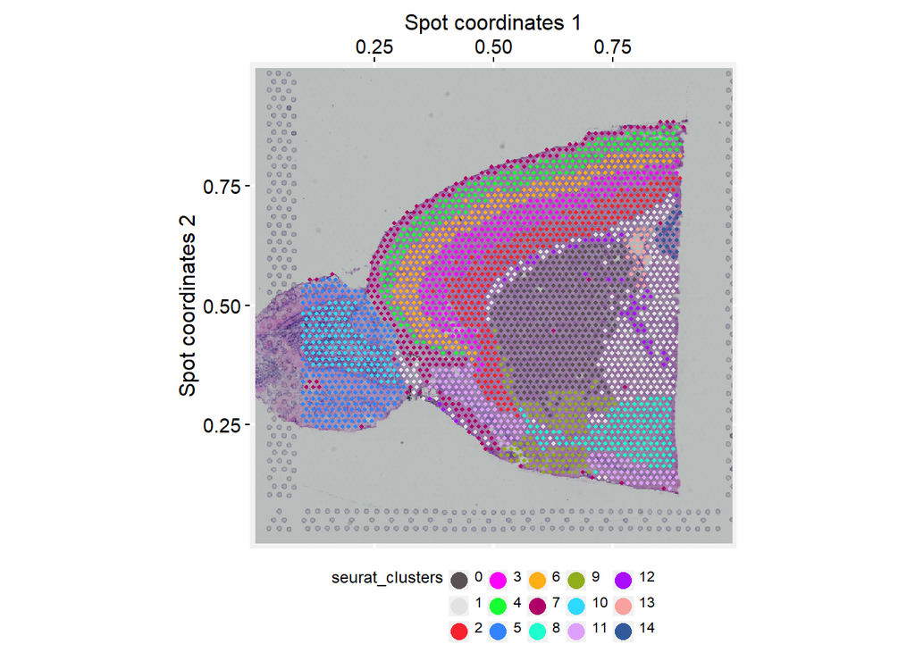

```r
# Set a reusable theme for spatial plots
spatial_theme <- theme_gspace_coords(theme = "th3", is_norm = TRUE,
                                     xlab = "Spot coordinates 1", ylab = "Spot coordinates 2")

# Left: 'seurat_clusters' annotation overlaid on tissue image
cpal1 <- DiscretePalette(nlevels(gs$seurat_clusters), "polychrome")

ggplot(gs) +
  annotation_gspace_image(gs) +
  geom_nodespace(mapping = aes(colour = seurat_clusters), size=0.8, pch=19) +
  scale_colour_discrete(palette = cpal1) +
  theme_gspace_legend(discrete_colour = TRUE) +
  spatial_theme
```

```r
head(spot_cellchat)
```

```
#> # A tibble: 6 × 14
#>   source_spot      target_spot distance_um source target ligand receptor    prob
#>   <chr>            <chr>             <dbl> <chr>  <chr>  <chr>  <chr>      <dbl>
#> 1 AAACAAGTATCTCCC… ACTAGTTGCG…        99.5 s_1    s_1    Fgf1   Fgfr1    0.0144
#> 2 AAACAAGTATCTCCC… ACTAGTTGCG…        99.5 s_1    s_1    Fgf1   Fgfr2    0.0160
#> 3 AAACAAGTATCTCCC… ACTAGTTGCG…        99.5 s_1    s_1    Fgf1   Fgfr3    0.0243
#> 4 AAACAAGTATCTCCC… ACTAGTTGCG…        99.5 s_1    s_1    Gas6   Axl      0.00520
#> 5 AAACAAGTATCTCCC… ACTAGTTGCG…        99.5 s_1    s_1    Mdk    Sdc4     0.0144
#> 6 AAACAAGTATCTCCC… ACTAGTTGCG…        99.5 s_1    s_1    Mdk    Ptprz1   0.0317
#> # ℹ 6 more variables: pval <dbl>, interaction_name <fct>,
#> #   interaction_name_2 <chr>, pathway_name <chr>, annotation <chr>,
#> #   evidence <chr>
```

## Load proximityNetwork() function

The proximityNetwork function receives a GraphSpace/PathwaySpace object with no edges and retrieves a GraphSpace/PathwaySpace object with edges between the nearest neighbor spots.

```r
proximityNetwork <- function(gs){
  # Get nodes slot from GraphSpace object
  nodes <- gs@nodes

  # Calculate the six most proximal neighbors of each spot, k=7 is set
  # because the spot itself also is considered as a neighbor with dist=0.
  # Eachs central spot is expected to have six neighbors due to the placement
  # of the spots on Visium slides.
  nnei = 6
  nnpg <- RANN::nn2(nodes[,c("x","y")], nodes[,c("x","y")], k=nnei+1)
  nn.dists <- as.data.frame(nnpg$nn.dists[,2:(nnei+1)])
  nn.idx <- as.data.frame(nnpg$nn.idx[,2:(nnei+1)])

  # The boundary spots are expected to have less than six neighbors, so the mean
  # distance of the first neighbors is calculated to find witch edges should be included or not.
  mdist<-1/(mean(1/nn.dists$V1))
  nn.dmean <- nn.dists

  message("Calculating the nearest neighbors distances...")

  # Each spot have at least one neighbor
  nn.dmean[,1]<-TRUE
  cols <- 2:ncol(nn.dists)
  nn.dmean[cols] <- (nn.dists[cols] >= 0.95 * mdist) &
    (nn.dists[cols] <= 1.05 * mdist)
  m_matrix <-nn.dmean * nn.idx

  # The nn.dmean have the info of the edges that should be included in the graph.
  # The nn.idx have the indices of the nodes.
  # Now these data will be converted to a edge list compatible with igraph nomenclature.

  message("Creating edges list...")

  m_matrix$idx <- row.names(m_matrix)
  edges_long <- tidyr::pivot_longer(m_matrix,names_to = "from",values_to = "to",cols = -idx)
  edges_long <- edges_long %>% dplyr::select(-from) %>% dplyr::filter(to!=0)
  colnames(edges_long) <- c("from","to")

  if(sum(nn.dmean) != length(edges_long$from)){
    message("Unexpected number of edges, something is depracated...")
    stop()
  }

  # The graph of proximity have a undirected profile, so edges_long have several duplicate edges in "from-to" and "to-from".
  edges_unique <- edges_long %>%
    dplyr::mutate(
      v1 = pmin(from, to),
      v2 = pmax(from, to)
    ) %>%
    dplyr::distinct(v1, v2) %>%
    dplyr::transmute(
      from = v1,
      to = v2
    )

  edges_unique[] <- lapply(edges_unique, as.numeric)
  message("Assigning spot names to edges...")

  edges_unique$from <- nodes$name[edges_unique$from]
  edges_unique$to   <- nodes$name[edges_unique$to]

  # Building the new igraph object with the selected edges
  nodes <- nodes %>% dplyr::relocate(name) %>% dplyr::select(-vertex)

  gs_graph <- igraph::graph_from_data_frame(
    d = edges_unique,
    vertices = nodes,
    directed = FALSE
  )

  # Converting the igraph object to GraphSpace object
  gs2 <- RGraphSpace::GraphSpace(gs_graph)

  gs@edges <- gs2@edges
  gs@graph <- gs_graph

  return(gs)
}
```

# Inserting edges on GraphSpace/PathwaySpace object

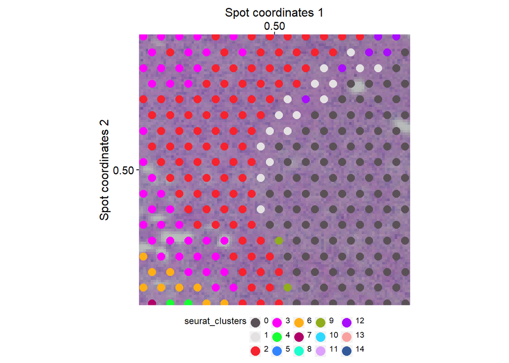

```r
# Plotting Visium dataset before inserting edges
ggplot(gs) +
  annotation_gspace_image(gs) +
  geom_edgespace() +
  scale_colour_discrete(palette = cpal1) +
  theme_gspace_legend(discrete_colour = TRUE) +
  spatial_theme +
  coord_cartesian(xlim=c(0.4,0.6), ylim = c(0.4,0.6)) +
  geom_nodespace(mapping = aes(colour = seurat_clusters), size=3, pch=19)
```

```r
# Insert edges to all nearest neighbors
gs <- proximityNetwork(gs)
```

```
#> Calculating the nearest neighbors distances...
#> Creating edges list...
#> Assigning spot names to edges...
#> Validating the 'igraph' object...
#> Creating a 'GraphSpace' object...
```

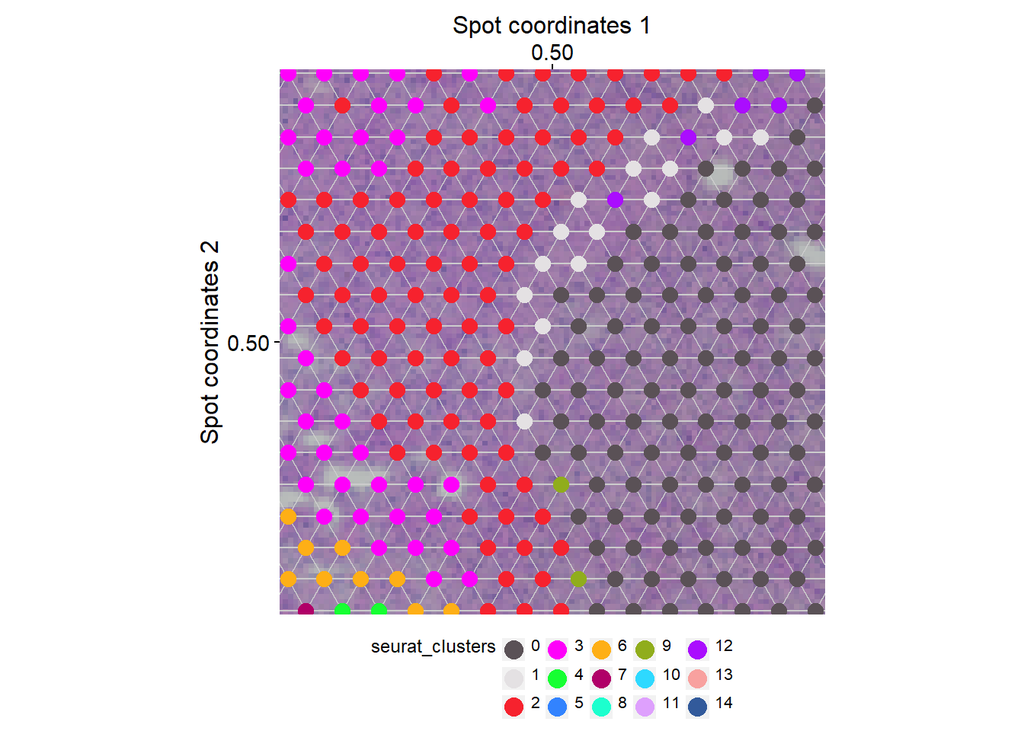

```r
# Create a backup object
gs3<- gs

# Plotting Visium dataset after inserting edges
ggplot(gs) +
  annotation_gspace_image(gs) +
  geom_edgespace() +
  scale_colour_discrete(palette = cpal1) +
  theme_gspace_legend(discrete_colour = TRUE) +
  spatial_theme +
  coord_cartesian(xlim=c(0.4,0.6), ylim = c(0.4,0.6)) +
  geom_nodespace(mapping = aes(colour = seurat_clusters), size=3, pch=19)
```

# Merging GraphSpace/PathwaySpace object edges with cell-cell communications

Cell-cell communications from CellChat are filtered by the proximity edges stored in the GraphSpace/PathwaySpace object. Thus, remain only cell-cell communications in which the ligand and the receptor are expressed in two neighbor spots.

```r
# Build all ligand-receptor pairs in the proximity edges
edges <- gs@edges
merge_edges <- edges %>%
  left_join(spot_cellchat,
            by = c("name1" = "source_spot","name2" = "target_spot"))
merge_edges <- merge_edges %>% dplyr::select(-c(vertex1,vertex2))
merge_edges$arrowType <- 1

# Store unique ligand-receptor pairs
un_merge <- merge_edges %>% select(ligand,receptor,interaction_name) %>% unique()
un_merge <- na.omit(un_merge)
head(un_merge)
```

```
#>   ligand receptor interaction_name
#> 1   Fgf1    Fgfr1       FGF1_FGFR1
#> 2   Fgf1    Fgfr2       FGF1_FGFR2
#> 3   Fgf1    Fgfr3       FGF1_FGFR3
#> 4   Gas6      Axl         GAS6_AXL
#> 5    Mdk     Sdc4         MDK_SDC4
#> 6    Mdk   Ptprz1       MDK_PTPRZ1
```

```r
# Get nodes slot from gs
nodes <- gs@nodes %>% dplyr::relocate(name) %>% dplyr::select(-vertex)
```